# Assignment 2

Ella Brayshaw

2023-03-13

#### Student number : 201669865

### Introduction

In this report I will be describing and evaluating the BOP2 trial design. I will begin by explaining the key features and steps. Then I will apply the BOP2 method to the RESERVE trial scenario that we have been provided with.

We are interested in looking at the progression between stage 1 to stage 2 of a phase II trial, then from stage 2 to a definitive phase III trial, these progressions are based on the posterior probability of futility. To begin to show the theory behind this idea, I will set $y_i$ to be the number of observations in the $n_i$ participants ($n_1$ = number of participants in stage 1 and $n_2 = n_1 + \tilde{n_2}$ = participants at the end of stage 2 ). $y_i$ follows a binomial distribution with probability of success, $\theta$, which itself follows a prior beta distribution with parameters $a_0$ and $b_0$.

After observing the response $y_i$ we can then calculate the posterior distribution using Bayes Theorem :
$$P(\theta | y_i) =
\frac{P(y_i|\theta)*P(\theta)}{P(y_i)}$$
This results in the posterior probability also following a beta distribution : $P(\theta|y_i)$ ~ beta($a_i$, $b_i$), where $a_i = a + y_i$ and $b_i = b + n_i - y_i$.

We utilise this posterior probability to determine progression through the probability of futility. We define the probability of futility as the probability of a response, $\theta < 0.5$ given the observed responses :
$$P(\theta < 0.5 | y_i)$$
We ideally want this to be low as the probability of observing a response is poor. To decide whether we carry on to the next stage we need to define a threshold which varies at each stage to compare this too, we define this threshold to be
$$C(n_i)
= 1 - \lambda(\frac{n_i}{n_2})^{\gamma}$$
. In general the rule would be that the trial would stop if $P(\theta < 0.5 | y_i) > C(n_i)$. In this report we will investigate choices of these stopping rule parameters $\lambda$ and $\gamma$.

I will now apply the BOP2 trial design to the RESERVE trial. The RESERVE (pREciSion markERs for VEnetoclax in multiple myeloma) trial is a clinical trial looking at the effects of treating patients with relapsed/refractory multiple myeloma (RRMM) with Vendex in combination with CyVenDex. The RESERVE trial is currently in phase II and we are wanting to investigate if the treatment has a large enough impact on tumor size to warrant a larger phase III trial. As there is uncertainty to the effectiveness and toxicity of the drug we want to work in 2 stages where the first stage has a lower sample size. This has better ethical, financial and efficiency considerations. In the this report I will be using $n_1$ participants in stage one of the trial and $\tilde{n_2}$ participants in stage 2. This leads to a total of $n_2 = n_1 + \tilde{n_2}$ participants at the end of stage 2.

To begin my exploration of the RESERVE trial I want to find the optimal values of $\lambda$ and $\gamma$ for a fixed $n_1$ and $n_2$ which result in a type I error rate of at most 0.05 under the null hypothesis of $H_0 : \theta =0.5$ and the type II error rate of at most 0.2 under the alternative hypothesis of $H_1 : \theta = 0.7$. Therefore I will evaluate the type I and type II error rates over a grid of values for $\lambda$ and $\gamma$ seeing which of these provides the error rates within the bounds. To determine the bounds for the parameters I used the fact that $0\leq \lambda \leq1$ and then plots to choose $\gamma \ge0$ which are shown below. I have looked at how the decision threshold, $C(n_i) = 1 - \lambda(\frac{n_i}{n_2})^{\gamma}$, changes for different values of $\gamma$ ( which I created with a sequence ). I chose the value of $\frac{n_i}{n_2}=0.5$, as $n_1 < n_2$ hence the fraction will always be less than 1. These plots show that beyond a value of $\gamma = 6$ there is little change to the value of the decision threshold, $C(n_i)$. Hence I will chose the bound $0\le \gamma \le 6$.

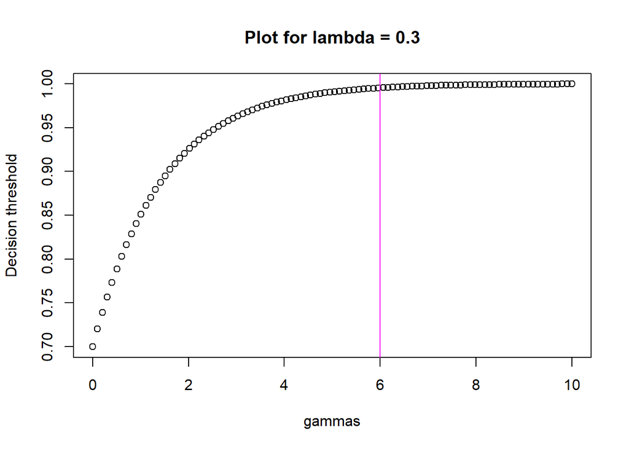

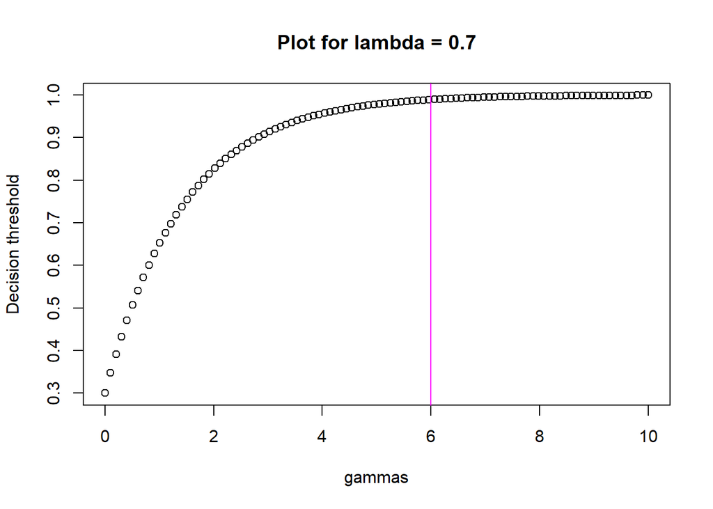

I have the created a grid of both the values of $\lambda$ and $\gamma$ over the chosen intervals and have named this “lambda_gamma”:

```r
lambda_gamma_seq <- expand.grid(lambda = seq(0, 1, length.out = 50),
                       gamma = seq(0, 6, length.out = 50))
```

```r
ptm <- proc.time()
source("./R/functions.R")
T1s <- apply(lambda_gamma_seq, 1, evaluate_seq_T1, n1 = 30, n2 = 60)
T2s <- apply(lambda_gamma_seq, 1, evaluate_seq_T2, n1 = 60, n2 = 120)
proc.time() - ptm
```

```
##    user  system elapsed
##   10.84    0.69   32.02
```

To evaluate the type I and type II error rate over this grid I require to call on a function that I have coded and stored in a R script of this R project called “Function.R”. Using the command below, I can easily make use of these functions without having to include the code each time.

```r
source("./R/functions.R")
```

In here is a function called “Type1_exact”, which I will use to evaluate the probability of a type 1 error over the values in “lambda_gamma”. A type 1 error is such that we declare a successful trial at the end of stage 2, under the null hypothesis: $\theta = 0.5$. This means that we require $P(\theta < 0.5 | y_1) < C(n_1)$ and $P(\theta < 0.5 | y_2) < C(n_2)$, we require stage 1 to be successful to move to stage 2 hence both of these are needed.

To begin I will set $n_1 = 30$ and $n_2 = 60$.

```r
source("./R/functions.R")
T1s <- apply(lambda_gamma_seq, 1, evaluate_seq_T1, n1=30, n2=60)
```

The code above shows me applying the grid of $\lambda$’s and $\gamma$’s over a function named “evaluate sequence” which allows us to evaluate another function named “Type1_exact” over the grid. The Type1_exact is a function of $\lambda$, $\gamma$, $n_1$ and $n_2$ which also uses another function in the folder, this function is called “prob_y1_y2” and it calculates the probability of observing the responses $y_1$ and $y_2$ within the number of participants $n_1$ and $n_2$ respectively. To test that this function has been coded correctly I wrote a unit test, this checks that the sum of the probabilities over values of $y_1$ and $y_2$ equals one. Below you can see where I have called the function from the “Unit_tests.R” folder; this returns a Boolean indicator “TRUE” which tells us that the sum does in fact equal one hence I know my probability is correct.

```r
source("./R/Unit_tests.R")
test_prob_y1_y2()
```

```
## [1] TRUE
```

To see which values of $\lambda$ and $\gamma$ are required to get a Type I error of $\le 0.05$, I will study plots. The plot for $\gamma$ vs Type I error here appears to be very unhelpful, hence I will begin by choosing a optimal $\lambda$. The clustering effect shown in graph is given by each cluster representing a different value of the other parameter $\gamma$, I have added lines (blue at Type 1 = 0.05 and green at $\lambda = 0.96$), I observe that to the right of $\lambda = 0.96$, the Type I error is always $\le 0.05$. However for certain choices of $\gamma$, the combination with $\lambda = 0.94$ and $\lambda = 0.92$ results in the desired bound for type I error.

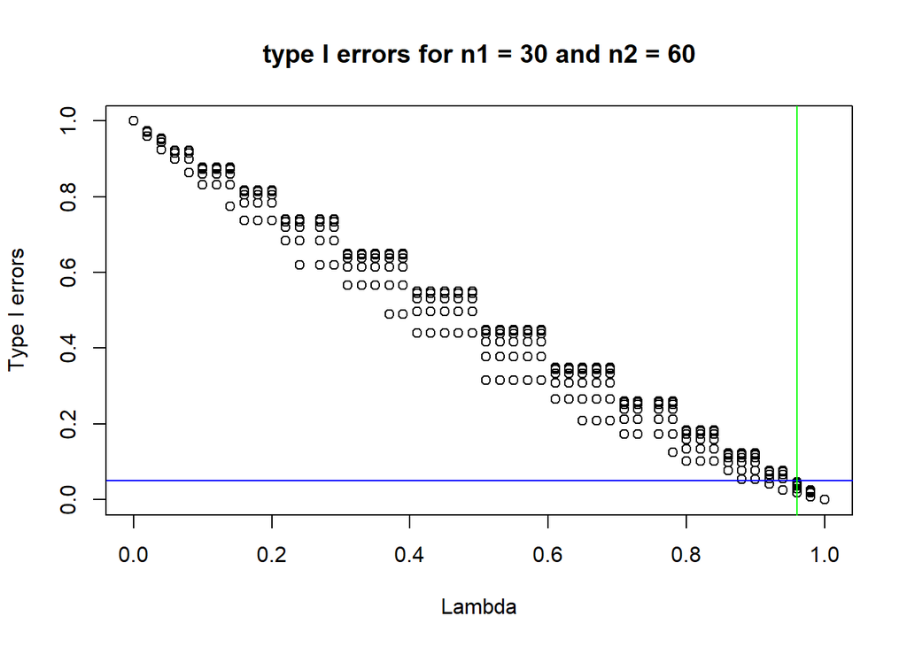

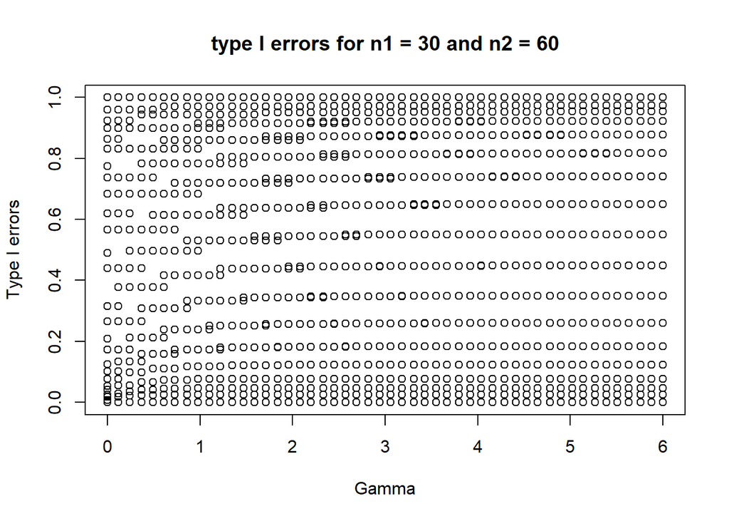

To make the plot of $\gamma$ vs type I error more useful, I will re-create the plot for only the suitable values of $\lambda$ mentioned above. From these plots I observe that for $\lambda \in [0.92,0.94]$, to achieve a Type 1 error $\le 0.05$ we would require $\gamma = 0$ which is not a reasonable choice as $\gamma$ is restricted to $[0,\infty]$. Hence I conclude that for us to achieve the maximum value of 0.05 I will choose $\lambda \in [0.96,1]$ and to find an optimal $\gamma > 0$ I will consider the type II error rate.

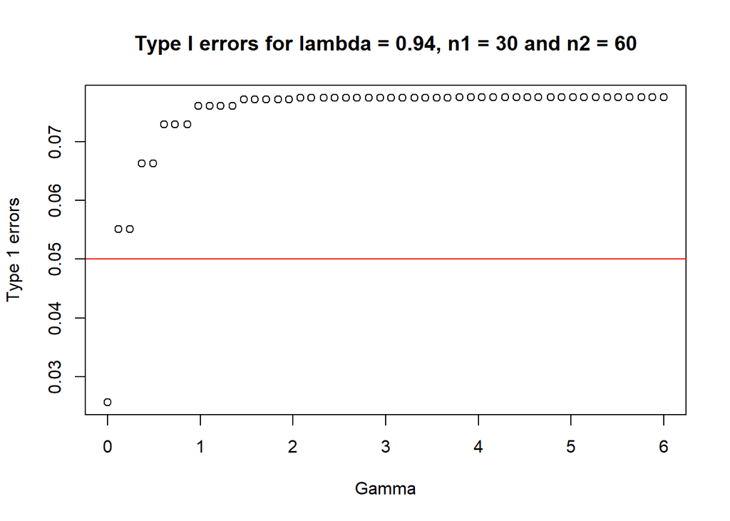

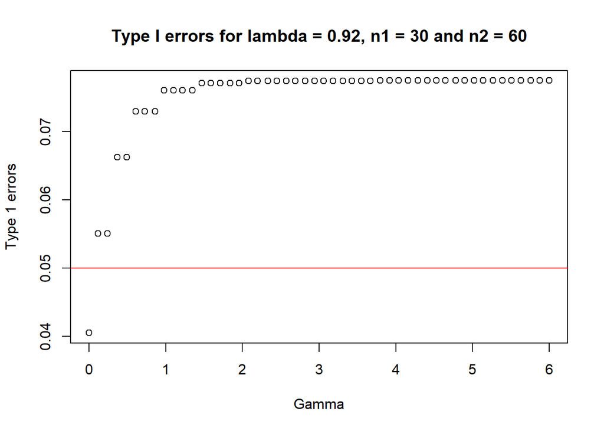

```r
source("./R/functions.R")
T2s <- apply(lambda_gamma_seq, 1, evaluate_seq_T2, n1=30, n2=60)
```

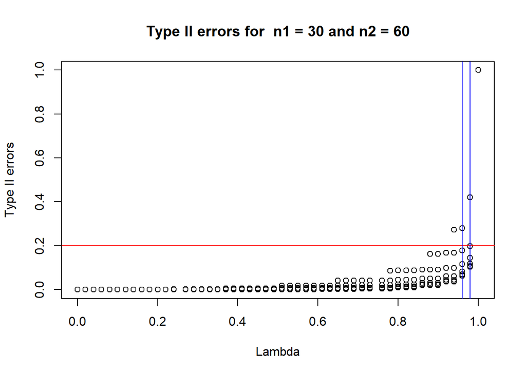

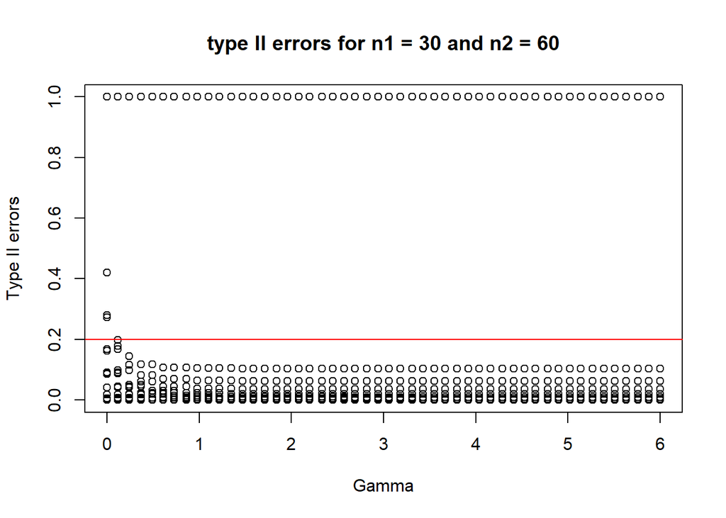

By observation of the $\gamma$ plot I see that there appears to a cluster linked to a value of $\lambda$ where type II error always equals 1, hence to find what this value of $\lambda$ is I will make a subsection of results which only includes rows where type 2 error = 1. From the print out of this I see that $\lambda = 1$ results in this type II error, this agrees with my previous conclusion I made.

```r
seq_T2s_bind$T2s <- round(seq_T2s_bind$T2s, 3)

sub5 <- seq_T2s_bind[seq_T2s_bind$T2s == 1, ]
head(sub5)
```

```
##     lambda gamma T2s
## 50       1  0.00   1
## 100      1  0.12   1
## 150      1  0.24   1
## 200      1  0.37   1
## 250      1  0.49   1
## 300      1  0.61   1
```

```r
# so when lambda = 1 T2 not in the range
```

Finally, to pick my value for $\gamma$ I will make 2 further subsections of the results, one for when $\lambda = 0.98$ and one for $\lambda = 0.96$, these match with my previous interval I have decided for $\lambda$. From inspection of the plots and the output of the two subsections, I see that the value of type II error drops below 0.2 for $\gamma \ge 0.12$ hence any value of $\gamma \ge 0.12$ would give us the desired results. We ideally want the probability of type II error to be as low as possible as this means our study would have greater power, this is important as it means we are more likely to detect a true result. To achieve this minimal type II error I would choose $\lambda = 0.96$ as there is a minimum type II error of 0.063 versus 0.103 for $\lambda = 0.98$. The plot shows us that the type II error rate appears to be consistent after $\gamma =1$ and from the output of the subsection I see that values of $\gamma \ge 2.08$ give the minimum type II error rate of 0.063. I will pick my optimal value of $\gamma$ to be 2.08 as this results in a minimal type II error rate, whilst slightly lower values of $\gamma$ results in lower type I error the difference between values is not as large.

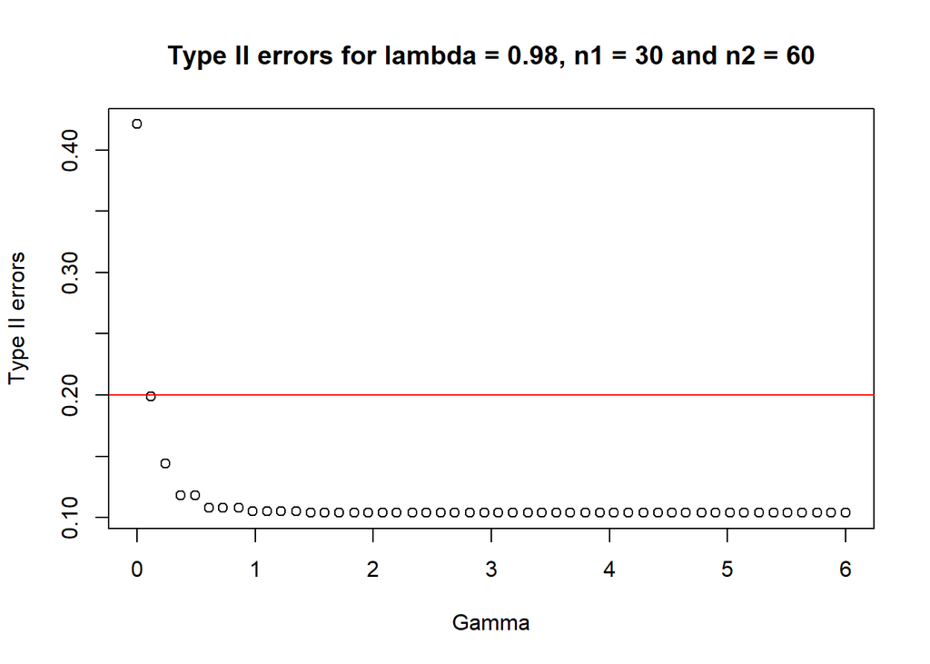

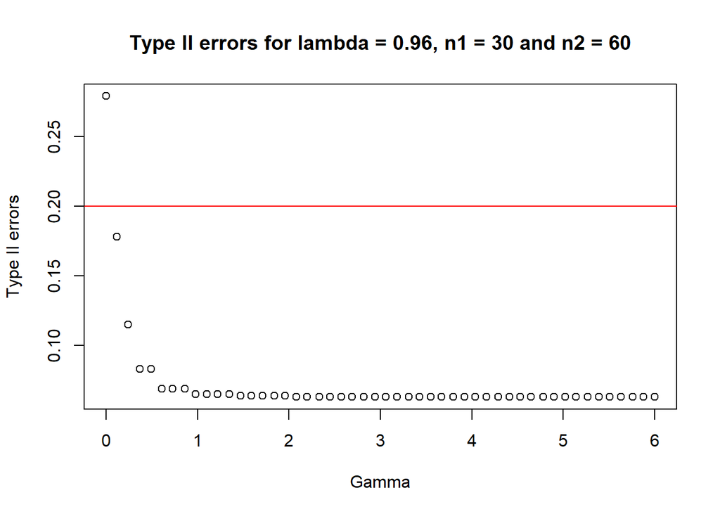

```r
T1_lambda0.96 <- seq_T1s_bind[seq_T1s_bind$lambda == 0.96, ]
T2_lambda0.96 <- seq_T2s_bind[seq_T2s_bind$lambda == 0.96, ]
T1_lambda0.96
T2_lambda0.96
```

[output not shown]

Hence for the sample size parameters of $n_1 = 30$ and $n_2 = 60$, I have found the optimal values of $\lambda = 0.96$ and $\gamma = 2.08$. And from inspection of subsections of grids made where $\lambda = 0.96$ I see that these would results a type I error rate of 0.0462 and type II error rate of 0.063 which satisfy the bounds.

#### $n_1 = 60$ and $n_2 = 120$

I will now go on to investigate how the decision rule parameters change as the sample size changes, I will follow similar steps to what I carried out previously. To start I shall simply double the previous sample sizes to $n_1 = 60$ and $n_2 = 120$, keeping the 1:2 ratio. As before I evaluate the function that calculate probability of Type I and Type II errors and combine the calculated type I and type II errors into a grid with their corresponding values of $\lambda$ and $\gamma$, I also round the values of the parameters to decimal places so that I am able to plot them but also make sub grids of them.

```r
source("./R/functions.R")
T1s_60 <- apply(lambda_gamma_seq, 1, evaluate_seq_T1, n1=60, n2=120)
T2s_60 <- apply(lambda_gamma_seq, 1, evaluate_seq_T2, n1=60, n2=120)

seq_T1s_60_bind <- cbind(lambda_gamma_seq, T1s_60)
seq_T1s_60_bind$lambda <- round(seq_T1s_60_bind$lambda, 2)
seq_T1s_60_bind$gamma <- round(seq_T1s_60_bind$gamma, 2)

seq_T2s_60_bind <- cbind(lambda_gamma_seq, T2s_60)
seq_T2s_60_bind$lambda <- round(seq_T2s_60_bind$lambda, 2)
seq_T2s_60_bind$gamma <- round(seq_T2s_60_bind$gamma, 2)
```

Looking at the plots for type I error vs the parameters, similar to before the plot for type 1 error rates vs $\gamma$ is not very useful. However from the plot for $\lambda$ I see that the type 1 error rate falls below 0.05 for more combinations with $\lambda = 0.94$. I will look into these combinations further as I previously found that the lower the value of $\lambda$ the lower the Type II error whilst having little impact on the type I error.I also observe that there is again a gamma corresponding to $\lambda = 0.92$ which gets us a type I error in the desired bound.

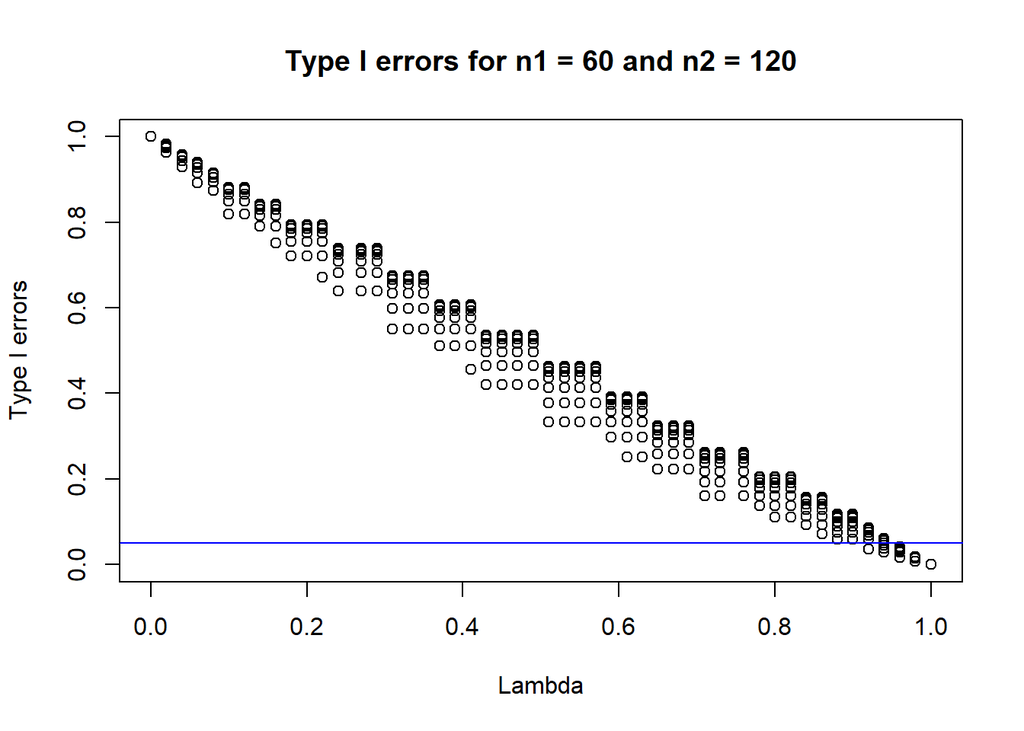

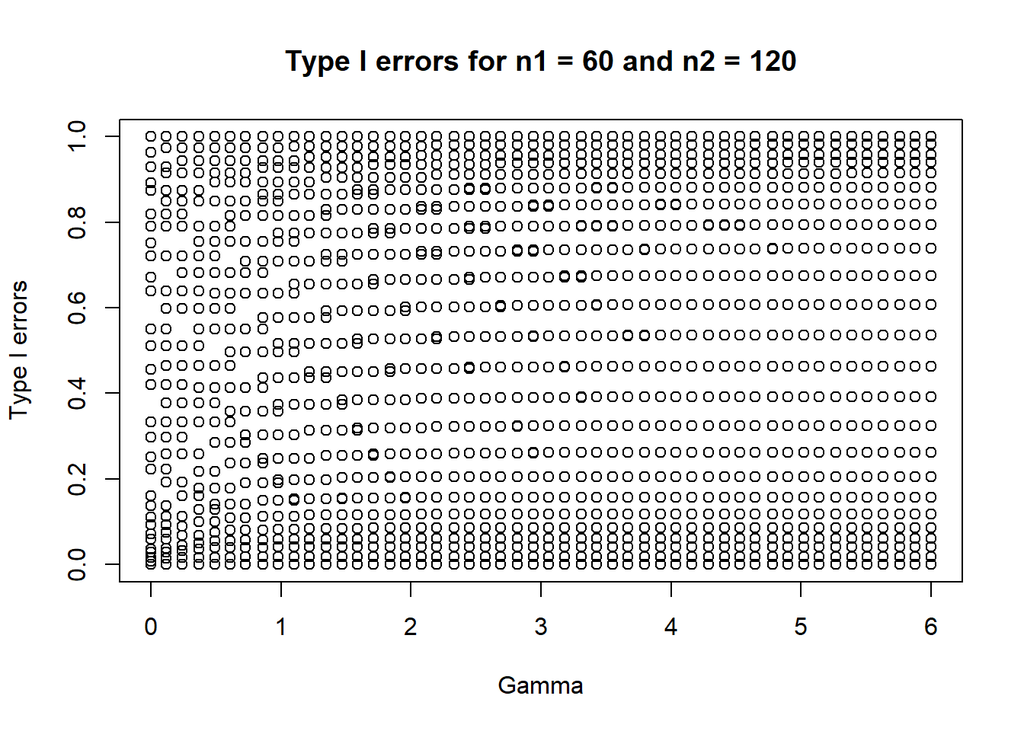

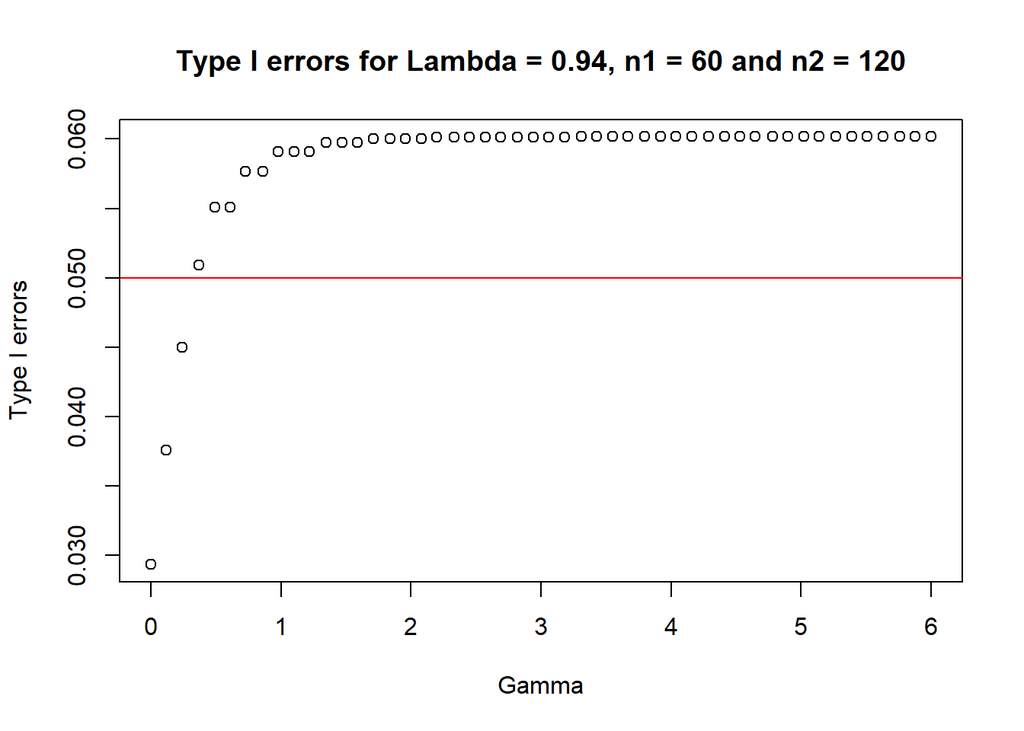

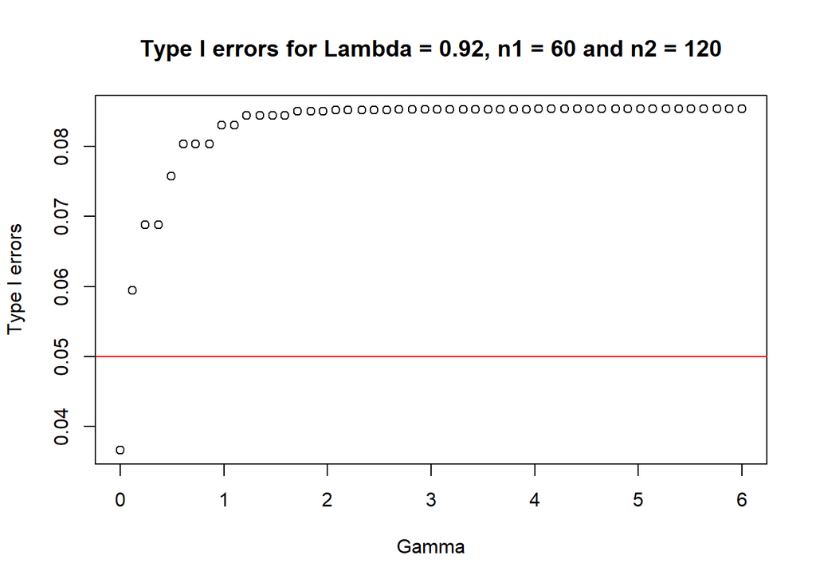

To choose $\gamma$ I will use the “head” function to view the upper subsection of my grid for when $\lambda = 0.94$, from this I see any value of $\gamma$ results in the desired bound for type II error so I consider type I error again. From this summary I see that for the desired maximum type I error to be met we require $\gamma \in (0,0.24]$, I will take $\gamma = 0.24$ as this results in bigger improvement to type II error wilst having little impact on type I error. This in combination with $\lambda = 0.94$ results in a type I error rate of 0.045 and a type II error rate of 0.011. These are both lower then the rates found for the smaller sample size, in particular the probability of type II error has decreased by 5.2% suggesting increasing sample size reduces the probability of stopping the trial early when results are actually significant, this is due to larger sample sizes reducing uncertainty in the trial.

```
##     lambda gamma     T1s_60
## 47    0.94  0.00 0.02934180
## 97    0.94  0.12 0.03758881
## 147   0.94  0.24 0.04501618
## 197   0.94  0.37 0.05093199
## 247   0.94  0.49 0.05509101
## 297   0.94  0.61 0.05509101
```

```
##     lambda gamma      T2s_60
## 47    0.94  0.00 0.036554935
## 97    0.94  0.12 0.020057681
## 147   0.94  0.24 0.010632453
## 197   0.94  0.37 0.005632273
## 247   0.94  0.49 0.003177429
## 297   0.94  0.61 0.003177429
```